# Analysis of honey bee wing shape in Algeria

Authors

Affiliations

Yamina Haider

University of Boumerdes, Algeria

Adam Tofilski

University of Agriculture in Krakow, Poland

Published

2026-10-05

## Libraries

```r
# calculations
library(geomorph)  # GPA
library(Morpho)  # CVA
library(IdentiFlyR)  # classification
library(phangorn)  #UPGMA

# plotting and visualization
library(ggplot2)  # plots
ggplot2::theme_set(theme_light())
library(rnaturalearth)  # maps
library(terra)  # raster maps
library(ggpubr)  # ggarrange
```

## Variable names

```r
p <- 19  # number of landmarks
k <- 2  # number of dimensions, in this case 2 for coordinates (x, y)

# create coordinates names used by IdentiFly
xyNames <- c("x1", "y1")
for (i in 2:p) {
  xyNames <- c(xyNames, paste0("x", i))
  xyNames <- c(xyNames, paste0("y", i))
}
xyNames
```

```
 [1] "x1"  "y1"  "x2"  "y2"  "x3"  "y3"  "x4"  "y4"  "x5"  "y5"  "x6"  "y6"
[13] "x7"  "y7"  "x8"  "y8"  "x9"  "y9"  "x10" "y10" "x11" "y11" "x12" "y12"
[25] "x13" "y13" "x14" "y14" "x15" "y15" "x16" "y16" "x17" "y17" "x18" "y18"
[37] "x19" "y19"
```

```r
# The number of principal components used is 2*p-4 = 34, which is equal to the
# degrees of freedom create principal components names used by prcomp
pcNames <- paste0("PC", 1:(2 * p - 4))
pcNames
```

```
 [1] "PC1"  "PC2"  "PC3"  "PC4"  "PC5"  "PC6"  "PC7"  "PC8"  "PC9"  "PC10"
[11] "PC11" "PC12" "PC13" "PC14" "PC15" "PC16" "PC17" "PC18" "PC19" "PC20"
[21] "PC21" "PC22" "PC23" "PC24" "PC25" "PC26" "PC27" "PC28" "PC29" "PC30"
[31] "PC31" "PC32" "PC33" "PC34"
```

```r
# define which landmarks are connected by lines in wireframe graph
link.x <- c(1, 1, 2, 2, 3, 3, 4, 4, 5, 6, 7, 7, 7, 8, 9, 9, 10, 11, 11, 12, 13, 14,
  15, 16, 17)
link.y <- c(2, 3, 4, 5, 6, 19, 6, 10, 12, 8, 8, 14, 19, 9, 10, 15, 11, 12, 16, 13,
  18, 15, 16, 17, 18)
links.apis <- cbind(link.x, link.y)

GP1 <- gridPar(pt.bg = "blue", link.col = "blue", pt.size = 1, tar.pt.bg = "red",
  tar.link.col = "red")

pointSize <- 1
```

## Read data

We used following datasets available at Zenodo: Haider & Tofilski, 2024, Haider & Tofilski, 2026, Tofilski, 2026 As references samples of *A. m. intermissa* and *A. m. sahariensis* we used supplementary data provided by Bakhchou et al., 2025

```r
wings <- read.csv("https://zenodo.org/records/18360081/files/DZ-2025-raw-coordinates.csv")
wings <- rbind(wings, read.csv("https://zenodo.org/records/18359322/files/DZ-2018-raw-coordinates.csv"))
wings <- rbind(wings, read.csv("https://zenodo.org/records/13939415/files/DZ-2024-raw-coordinates.csv"))

geoData <- read.csv("https://zenodo.org/records/18360081/files/DZ-2025-data.csv")
geoData <- rbind(geoData, read.csv("https://zenodo.org/records/18359322/files/DZ-2018-data.csv"))
geoData2024 <- read.csv("https://zenodo.org/records/13939415/files/DZ-2024-data.csv")
geoData2024$notes <- "Mediterranean"
geoData <- rbind(geoData, geoData2024)

names(geoData)[names(geoData) == "notes"] <- "climate"
geoData$climate <- factor(geoData$climate, levels = c("desert", "semiarid", "Mediterranean"))  #specify order

# read reference of A. m. intermissa and A. m. sahariensis
dataMA <- read.csv("MA.csv", sep = ";")
# use only A. m. intermissa and A. m. sahariensis
dataMA <- dataMA[dataMA$notes %in% c("A. m. intermissa", "A. m. sahariensis"), ]

wingsMA <- dataMA[, c("file", xyNames)]
wings <- rbind(wings, wingsMA)

geoDataMA <- dataMA[, c("file", "sample", "latitude", "longitude", "date")]

geoDataMA <- data.frame(file = dataMA$file, sample = dataMA$sample, latitude = dataMA$latitude,
  longitude = dataMA$longitude, date = dataMA$date, resolution = NA, climate = dataMA$notes)
geoDataDZ <- geoData
geoData <- rbind(geoData, geoDataMA)
```

## GPA

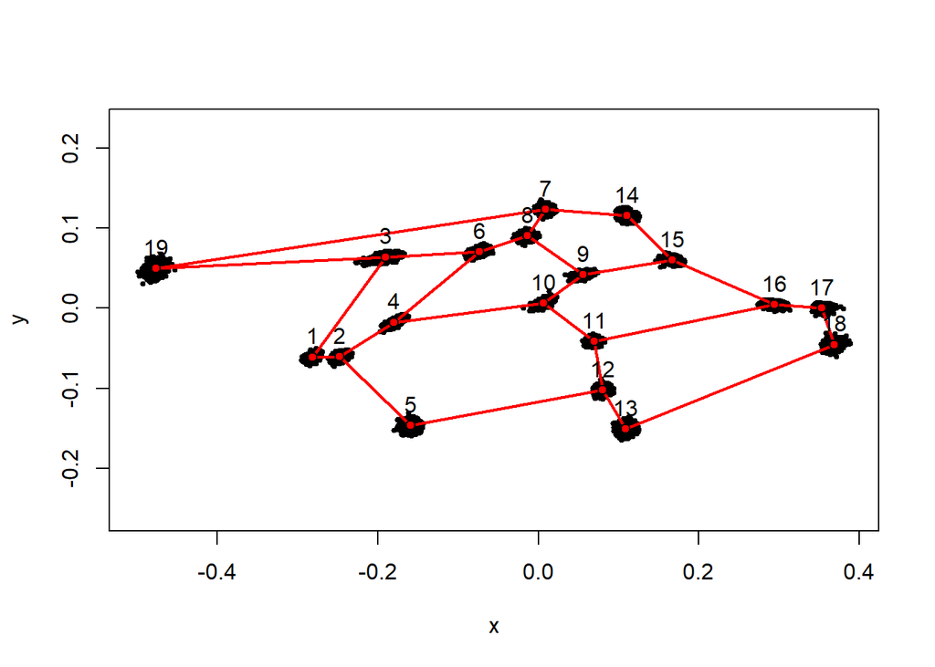

```r
# Convert from 2D array to 3D array
wings3D <- arrayspecs(wings[xyNames], p, k)
dimnames(wings3D)[[3]] <- wings$file

# Align the coordinates using Generalized Procrustes Analysis
GPA <- gpagen(wings3D, print.progress = FALSE)

# plot landmarks after alignment
plotAllSpecimens(GPA$coords, links = links.apis, label = TRUE, plot_param = list(pt.bg = "black",
  pt.cex = 0.5, mean.bg = "red", mean.cex = 1, link.col = "red", txt.pos = 3, txt.cex = 1))
```

```r
# Convert from 3D array to 2D array
wingsAligned <- two.d.array(GPA$coords)
colnames(wingsAligned) <- xyNames
wingsAligned <- as.data.frame(wingsAligned)

samples <- aggregate(wingsAligned, by = list(geoData$sample), FUN = mean)
samples <- data.frame(samples, row.names = 1)  # move column 1 to row names

geoDataSample <- aggregate(geoData[c("latitude", "longitude", "date")], by = list(geoData$sample),
  FUN = mean)
gr <- aggregate(climate ~ sample, data = geoData, FUN = unique)
geoDataSample$climate <- gr$climate

geoDataSample <- data.frame(geoDataSample, row.names = 1)  # move column 1 to row names

samples <- cbind(samples, geoDataSample)
samples$climate <- factor(samples$climate, levels = c("desert", "semiarid", "Mediterranean"))  #specify order
samplesAll <- samples
samples <- samplesAll[samplesAll$climate %in% c("desert", "semiarid", "Mediterranean"),
  ]
```

## Sample size

```r
# number of wings
nrow(geoDataDZ)
```

```
[1] 4654
```

```r
# number of wings per species
table(geoDataDZ$climate)
```

```
       desert      semiarid Mediterranean
          907          1039          2708
```

```r
# number of samples
nrow(samples)
```

```
[1] 145
```

```r
# number of samples per species
table(samples$climate)
```

```
       desert      semiarid Mediterranean
           23            43            79
```

## Maps

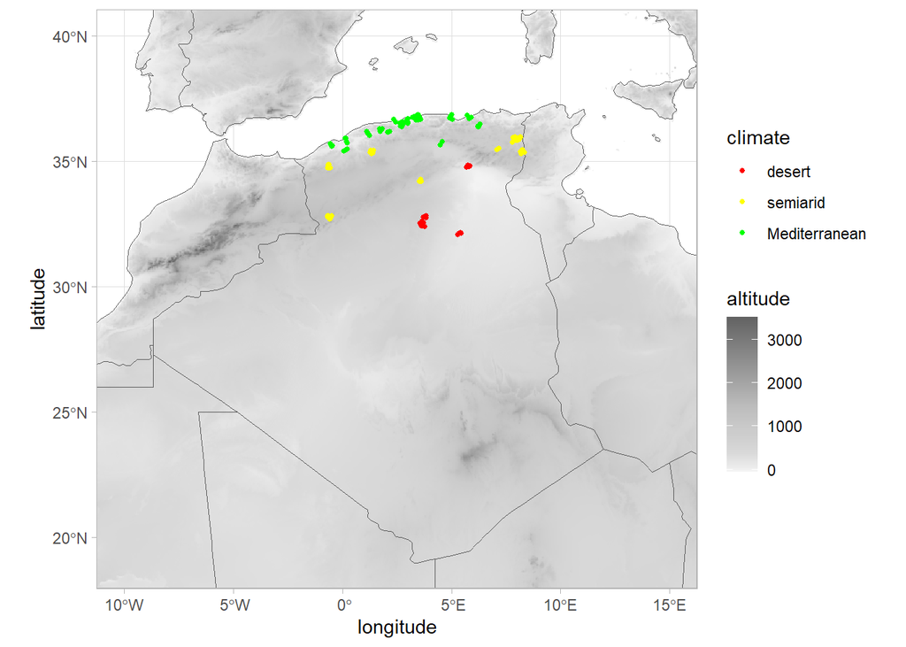

```r
# Read elevation data
elev <- rast("X:/WorldClim/wc2.1_2.5m_elev.tif")

colorElev <- colorRampPalette(c("#f7f7f7", "#f0f0f0", "#d9d9d9", "#bdbdbd", "#636363"),
  bias = 3)

xMin <- -10
xMax <- 15
yMin <- 19
yMax <- 40
e <- ext(xMin - 5, xMax + 5, yMin - 5, yMax + 5)
elev <- crop(elev, e)
elevDf <- as.data.frame(elev, xy = TRUE, na.rm = TRUE)
colnames(elevDf) <- c("longitude", "latitude", "altitude")

world <- ne_countries(scale = "medium", returnclass = "sf")

ggplot(data = world) + geom_raster(data = elevDf, aes(longitude, latitude, fill = altitude)) +
  scale_fill_gradientn(colours = colorElev(100), guide = guide_colorbar(order = 3)) +
  geom_sf(fill = NA) + coord_sf(xlim = c(xMin, xMax), ylim = c(yMin, yMax)) + geom_jitter(data = samples,
  aes(x = longitude, y = latitude, color = climate), size = pointSize, width = 0.1,
  height = 0.1) + scale_color_manual(values = c("red", "yellow", "green"), guide = guide_legend(order = 1)) +
  theme(legend.position = "right")
```

## Classification as lineages

Comparison with lineages dataset Nawrocka et al., (2018a), Nawrocka et al., (2018b)

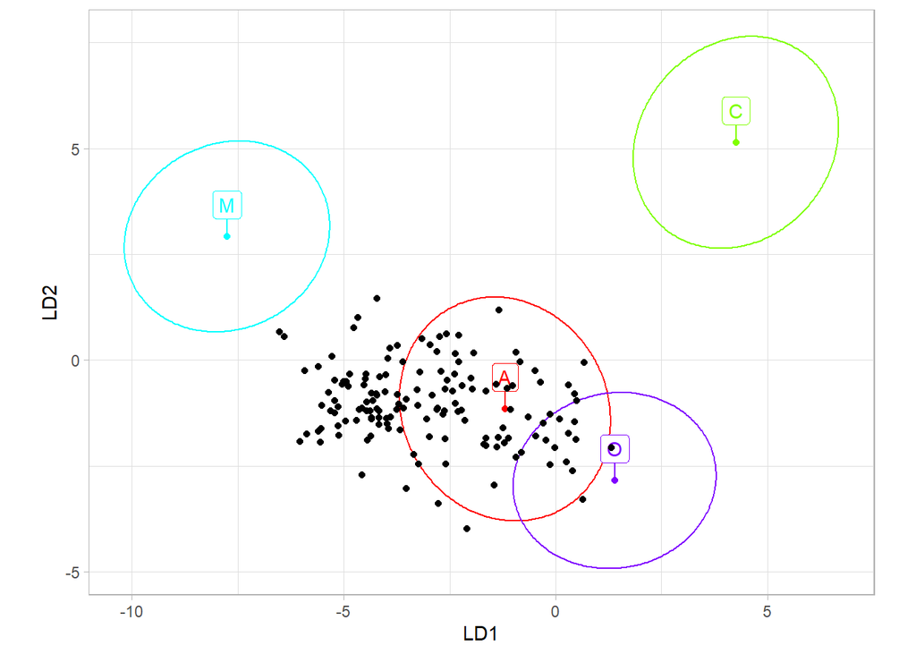

```r
idData <- xml2gmLdaData("https://zenodo.org/records/14054009/files/apis-mellifera-lineage.dw.xml")

id <- gmLdaData2id(idData, samples[, xyNames], average = FALSE)

id$plot
```

```r
table(id$id$group)
```

```
  A
145
```

```r
pTab <- as.data.frame(id$P)

# colony with minimum probability of classification as lineage A
pTab[which.min(pTab$A), ]
```

```
               A        C        M        O
DZ-0070 1.34e-08 3.95e-58 3.32e-19 4.39e-25
```

```r
# colony with maximum probability of classification as lineage C
pTab[which.max(pTab$C), ]
```

```
            A        C        M        O
DZ-0042 0.192 4.61e-18 5.84e-27 1.18e-05
```

```r
# colony with maximum probability of classification as lineage M
pTab[which.max(pTab$M), ]
```

```
              A        C        M        O
DZ-0044 0.00123 5.74e-31 9.82e-11 3.44e-17
```

```r
# colony with maximum probability of classification as lineage O
pTab[which.max(pTab$O), ]
```

```
             A        C        M        O
DZ-0029 0.0256 3.28e-20 7.28e-35 0.000291
```

## PCA

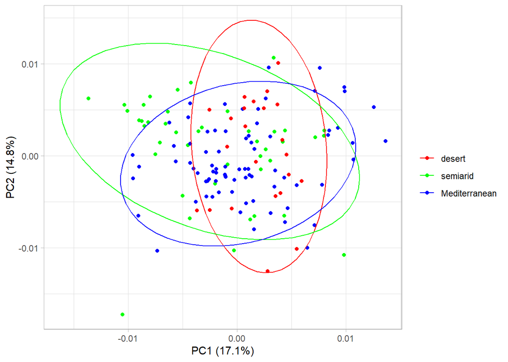

```r
PCA <- prcomp(samples[, xyNames])
PCscores <- as.data.frame(PCA$x)
PCscores <- cbind(PCscores, samples[, c("latitude", "longitude", "climate")])

# create plot labels
variance.tab <- summary(PCA)$importance
variance <- variance.tab["Proportion of Variance", "PC1"]
variance <- round(100 * variance, 1)
label.x <- paste0("PC1 (", variance, "%)")
variance <- variance.tab["Proportion of Variance", "PC2"]
variance <- round(100 * variance, 1)
label.y <- paste0("PC2 (", variance, "%)")

grN <- 3
figPca <- ggplot(PCscores, aes(x = PC1, y = PC2, color = climate)) + geom_point() +
  scale_color_manual(name = "", values = rainbow(grN)) + stat_ellipse() + xlab(label.x) +
  ylab(label.y)
figPca
```

## Differences between climates

```r
samples3D <- arrayspecs(samples[, xyNames], p, k)
gdf <- geomorph.data.frame(coords = samples3D, climate = samples$climate)
gdf$climate <- factor(gdf$climate)


fit <- procD.lm(coords ~ climate, data = gdf)
summary(fit)
```

```
Analysis of Variance, using Residual Randomization
Permutation procedure: Randomization of null model residuals
Number of permutations: 1000
Estimation method: Ordinary Least Squares
Sums of Squares and Cross-products: Type I
Effect sizes (Z) based on F distributions

           Df      SS       MS   Rsq  F    Z Pr(>F)
climate     2 0.00127 0.000635 0.053  4 5.07  0.001 ***
Residuals 142 0.02253 0.000159 0.947
Total     144 0.02380
---
Signif. codes:  0 '***' 0.001 '**' 0.01 '*' 0.05 '.' 0.1 ' ' 1

Call: procD.lm(f1 = coords ~ climate, data = gdf)
```

```r
PW <- pairwise(fit, groups = gdf$climate)
# distances among means
summary(PW, confidence = 0.95, test.type = "dist")
```

```
Pairwise comparisons

Groups: desert semiarid Mediterranean

RRPP: 1000 permutations

LS means:
Vectors hidden (use show.vectors = TRUE to view)

Pairwise distances between means, plus statistics
                             d UCL (95%)    Z Pr > d
desert:semiarid        0.00739   0.00440 4.67  0.001
desert:Mediterranean   0.00474   0.00411 2.51  0.005
semiarid:Mediterranean 0.00513   0.00329 3.84  0.001
```

```r
# correlation between mean vectors (angles in degrees)
summary(PW, confidence = 0.95, test.type = "VC", angle.type = "deg")
```

```
Pairwise comparisons

Groups: desert semiarid Mediterranean

RRPP: 1000 permutations

LS means:
Vectors hidden (use show.vectors = TRUE to view)

Pairwise statistics based on mean vector correlations
                       r angle UCL (95%)    Z Pr > angle
desert:semiarid        1 0.424     0.252 4.67      0.001
desert:Mediterranean   1 0.272     0.236 2.51      0.005
semiarid:Mediterranean 1 0.294     0.189 3.84      0.001
```

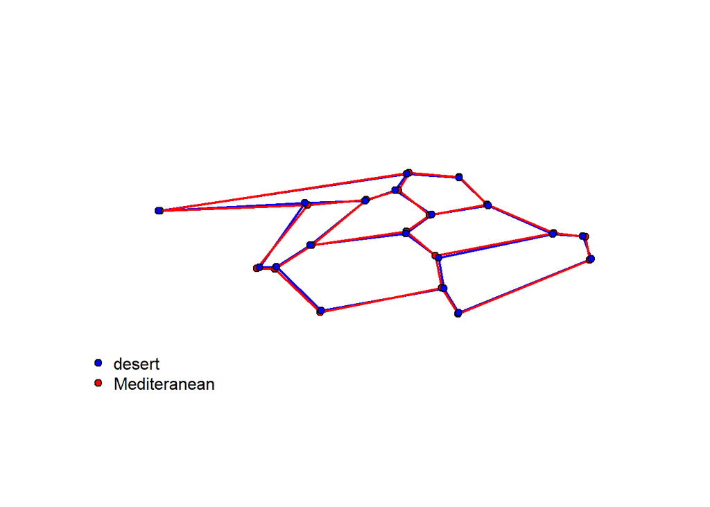

```r
# desert - Mediteranean
DZde_mean <- mshape(samples3D[, , which(samples$climate == "desert")])
DZme_mean <- mshape(samples3D[, , which(samples$climate == "Mediterranean")])
plotRefToTarget(DZde_mean, DZme_mean, mag = 4, links = links.apis, gridPars = GP1,
  method = "points")
legend("bottomleft", legend = c("desert", "Mediteranean"), pch = 21, pt.bg = c("blue",
  "red"), bty = "n")
```

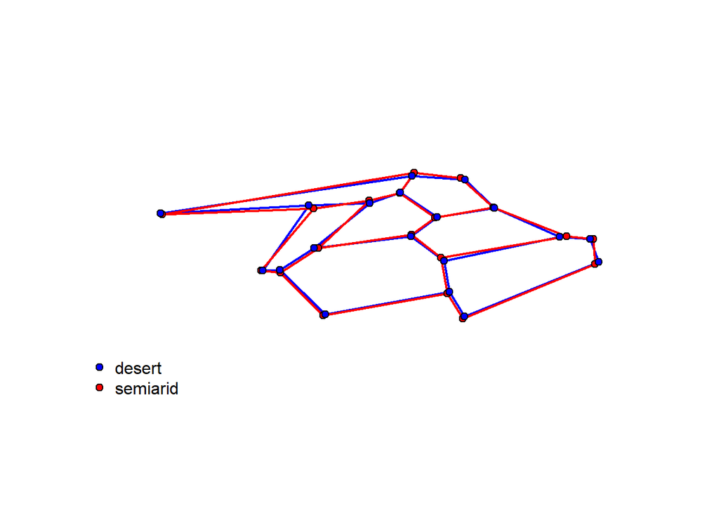

```r
# desert-semiarid
DZse_mean <- mshape(samples3D[, , which(samples$climate == "semiarid")])
plotRefToTarget(DZde_mean, DZse_mean, mag = 4, links = links.apis, gridPars = GP1,
  method = "points")
legend("bottomleft", legend = c("desert", "semiarid"), pch = 21, pt.bg = c("blue",
  "red"), bty = "n")
```

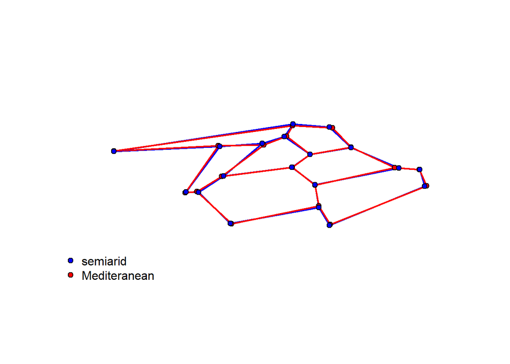

```r
# semiarid-Mediteranean
plotRefToTarget(DZse_mean, DZme_mean, mag = 4, links = links.apis, gridPars = GP1,
  method = "points")
legend("bottomleft", legend = c("semiarid", "Mediteranean"), pch = 21, pt.bg = c("blue",
  "red"), bty = "n")
```

## LDA climate

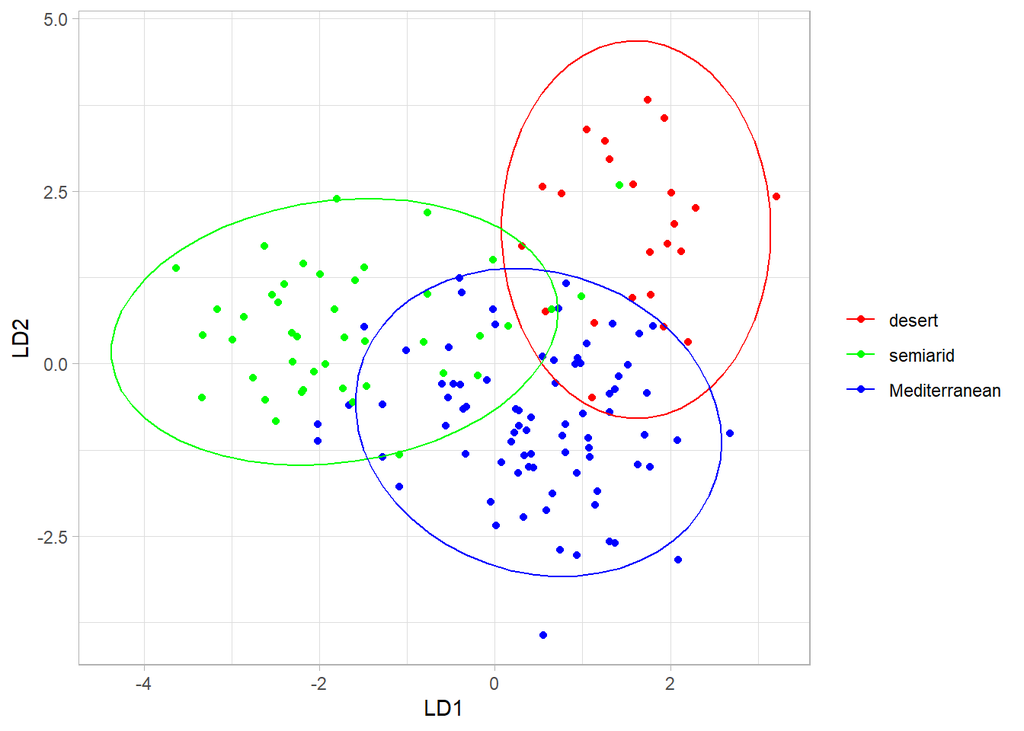

```r
# use equal prior probability for all groups
grN <- length(unique(PCscores$climate))  # number of groups
sample.cva <- CVA(PCscores[pcNames], PCscores$climate, rounds = 10000, cv = TRUE,
  prior = rep(1/grN, grN))
sample.cva.scores <- as.data.frame(sample.cva$CVscores)
# rename variable names from CV to LD otherwise use `CV 1`
colnames(sample.cva.scores) <- gsub("CV ", "LD", colnames(sample.cva.scores))
# sample.cva.scores <- cbind(sample.geoData, sample.cva.scores)
sample.cva.scores$climate <- PCscores$climate

figLda <- ggplot(sample.cva.scores, aes(x = LD1, y = LD2, color = climate)) + geom_point() +
  scale_color_manual(name = "", values = rainbow(grN)) + stat_ellipse()
figLda
```

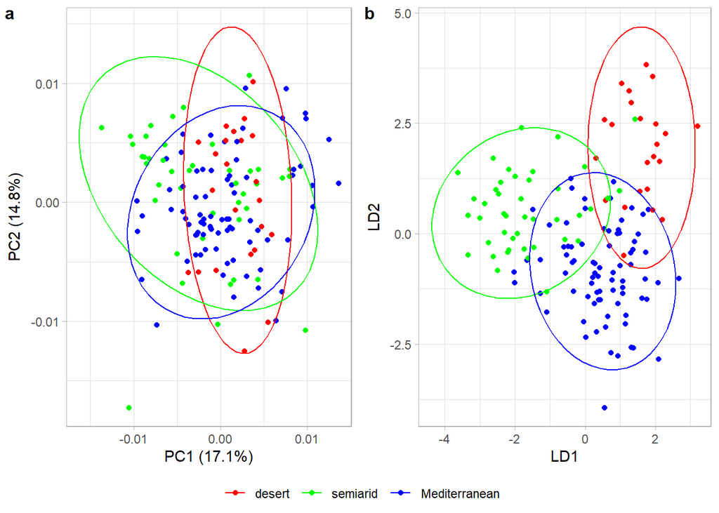

```r
ggarrange(figPca, figLda, labels = c("a", "b"), font.label = list(size = 12, face = "bold"),
  ncol = 2, nrow = 1, common.legend = TRUE, legend = "bottom")
```

```r
# Confusion matrix Classification of the samples to groups
LDA.class <- typprobClass(sample.cva$CVscores, groups = as.factor(sample.cva.scores$climate),
  outlier = 0)
print(LDA.class)
```

```
 cross-validated classification results in frequencies

                desert Mediterranean semiarid
  desert            22             1        0
  semiarid           4             5       34
  Mediterranean      5            64       10


 cross-validated classification result in %

                 desert Mediterranean semiarid
  desert        95.6522        4.3478   0.0000
  semiarid       9.3023       11.6279  79.0698
  Mediterranean  6.3291       81.0127  12.6582


 overall classification accuracy: 82.75862 %

 Kappa statistic: 0.73781
```

```r
# Mahalanobis distances between groups
knitr::kable(as.data.frame(as.matrix(sample.cva$Dist$GroupdistMaha)), digits = 3)
```

|  | desert | semiarid | Mediterranean |
| --- | --- | --- | --- |
| desert | 0.00 | 3.54 | 2.98 |
| semiarid | 3.54 | 0.00 | 2.55 |
| Mediterranean | 2.98 | 2.55 | 0.00 |

```r
# pairwise probabilities of differences between groups
knitr::kable(as.data.frame(as.matrix(sample.cva$Dist$probsMaha)), digits = 5)
```

|  | desert | semiarid | Mediterranean |
| --- | --- | --- | --- |
| desert | 0e+00 | 1e-04 | 1e-04 |
| semiarid | 1e-04 | 0e+00 | 1e-04 |
| Mediterranean | 1e-04 | 1e-04 | 0e+00 |

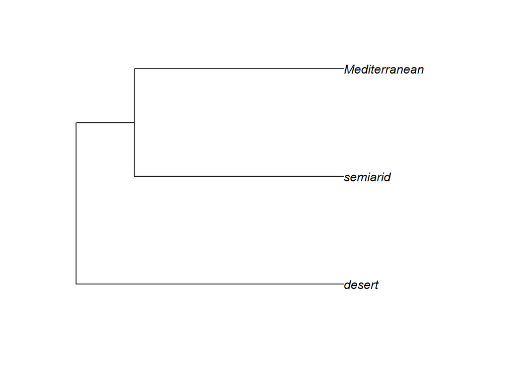

```r
MD <- as.matrix(sample.cva$Dist$GroupdistMaha)
tree <- upgma(MD)
plot(tree)
```

## LDA subspecies

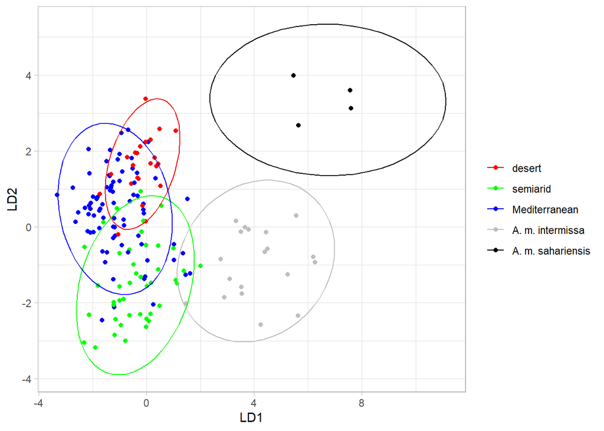

```r
PCA <- prcomp(samplesAll[, xyNames])
PCscores <- as.data.frame(PCA$x)
PCscores$gr <- geoDataSample$climate

# use equal prior probability for all groups
grN <- length(unique(PCscores$gr))  # number of groups
sample.cva <- CVA(PCscores[pcNames], PCscores$gr, rounds = 10000, cv = TRUE, prior = rep(1/grN,
  grN))
sample.cva.scores <- as.data.frame(sample.cva$CVscores)
# rename variable names from CV to LD otherwise use `CV 1`
colnames(sample.cva.scores) <- gsub("CV ", "LD", colnames(sample.cva.scores))
# sample.cva.scores <- cbind(sample.geoData, sample.cva.scores)
sample.cva.scores$gr <- PCscores$gr

ggplot(sample.cva.scores, aes(x = LD1, y = LD2, color = gr)) + geom_point() + scale_color_manual(name = "",
  values = c(rainbow(3), "gray", "black")) + stat_ellipse()
```

```r
# Confusion matrix Classification of the samples to groups
LDA.class <- typprobClass(sample.cva$CVscores, groups = as.factor(sample.cva.scores$gr),
  outlier = 0)
print(LDA.class)
```

```
 cross-validated classification results in frequencies

                    A. m. intermissa A. m. sahariensis desert Mediterranean
  desert                           0                 0     21             2
  semiarid                         0                 0      1             7
  Mediterranean                    1                 0      6            60
  A. m. intermissa                18                 0      0             0
  A. m. sahariensis                0                 4      0             0

                    semiarid
  desert                   0
  semiarid                35
  Mediterranean           12
  A. m. intermissa         1
  A. m. sahariensis        0


 cross-validated classification result in %

                    A. m. intermissa A. m. sahariensis   desert Mediterranean
  desert                      0.0000            0.0000  91.3043        8.6957
  semiarid                    0.0000            0.0000   2.3256       16.2791
  Mediterranean               1.2658            0.0000   7.5949       75.9494
  A. m. intermissa           94.7368            0.0000   0.0000        0.0000
  A. m. sahariensis           0.0000          100.0000   0.0000        0.0000

                    semiarid
  desert              0.0000
  semiarid           81.3953
  Mediterranean      15.1899
  A. m. intermissa    5.2632
  A. m. sahariensis   0.0000


 overall classification accuracy: 82.14286 %

 Kappa statistic: 0.78912
```

```r
# Mahalanobis distances between groups
knitr::kable(as.data.frame(as.matrix(sample.cva$Dist$GroupdistMaha)), digits = 3)
```

|  | desert | semiarid | Mediterranean | A. m. intermissa | A. m. sahariensis |
| --- | --- | --- | --- | --- | --- |
| desert | 0.00 | 3.47 | 2.71 | 5.40 | 8.43 |
| semiarid | 3.47 | 0.00 | 2.52 | 5.10 | 9.05 |
| Mediterranean | 2.71 | 2.52 | 0.00 | 5.45 | 9.07 |
| A. m. intermissa | 5.40 | 5.10 | 5.45 | 0.00 | 7.10 |
| A. m. sahariensis | 8.43 | 9.05 | 9.07 | 7.10 | 0.00 |

```r
# pairwise probabilities of differences between groups
knitr::kable(as.data.frame(as.matrix(sample.cva$Dist$probsMaha)), digits = 5)
```

|  | desert | semiarid | Mediterranean | A. m. intermissa | A. m. sahariensis |
| --- | --- | --- | --- | --- | --- |
| desert | 0e+00 | 1e-04 | 2e-04 | 1e-04 | 1e-04 |
| semiarid | 1e-04 | 0e+00 | 1e-04 | 1e-04 | 1e-04 |
| Mediterranean | 2e-04 | 1e-04 | 0e+00 | 1e-04 | 1e-04 |
| A. m. intermissa | 1e-04 | 1e-04 | 1e-04 | 0e+00 | 1e-04 |
| A. m. sahariensis | 1e-04 | 1e-04 | 1e-04 | 1e-04 | 0e+00 |

## References

Bakhchou, S., Aglagane, A., Tofilski, A., Mokrini, F., Er-Rguibi, O., El Mouden, E. H., Machlowska, J., Fellahi, S., & Mohssine, E. H. (2025). Morphological Diversity of Moroccan Honey Bees (*Apis mellifera* L. 1758): Insights from a Geometric Morphometric Study of Wing Venation in Honey Bees from Different Climatic Regions. Diversity, 17(8), 527. https://doi.org/10.3390/d17080527

Haider, Y., & Tofilski, A. (2024). Fore wing images of honey bees (*Apis mellifera*) from Algeria 2024 [Dataset]. Zenodo. https://doi.org/10.5281/zenodo.13939415

Haider, Y., & Tofilski, A. (2026). Fore wing images of honey bees (*Apis mellifera*) from Algeria 2025 [Dataset]. Zenodo. https://doi.org/10.5281/zenodo.18360081

Nawrocka, A., Kandemir, İ., Fuchs, S., & Tofilski, A. (2018). Computer software for identification of honey bee subspecies and evolutionary lineages. Apidologie, 49(2), 172-184. https://doi.org/10.1007/s13592-017-0538-y

Nawrocka, A., Kandemir, İ., Fuchs, S., & Tofiilski, A. (2018). Dataset: Computer software for identification of honey bee subspecies and evolutionary lineages. Apidologie, 49, 172–184. https://doi.org/10.5281/zenodo.7567336

Tofilski, A. (2026). Fore wing images of honey bees (*Apis mellifera*) from Algeria 2018 [Dataset]. Zenodo. https://doi.org/10.5281/zenodo.18359322